# HW2

```python
# 먼저 라이브러리 설치 (설치되지 않은 경우)
!pip install pyreadstat
```

```python
# pyreadstat으로 Stata 파일 읽기
import pyreadstat

df, meta = pyreadstat.read_dta('ct_felon2.dta')

# 데이터 확인
print(df.head())
```

```
   v08        age     crime  days_served  timesincerelease  mail  reg  v12
0  0.0  49.770206      SALE   357.669403          2.650674   0.0  0.0  0.0
1  0.0  33.800426  BURGLARY   594.564453          0.677027   1.0  0.0  0.0
2  1.0  22.849304   ASSAULT   286.603333          0.633061   0.0  0.0  0.0
3  0.0  41.508663  CRIMINAL   580.255066          1.544256   0.0  0.0  0.0
4  0.0  27.735893  BURGLARY   813.326172          0.649590   1.0  0.0  0.0
```

### 1. 로지스틱 회귀 계수 추정 및 95% 신뢰 구간

```python
print(df.dtypes)
```

```
v08                 float64
age                 float64
crime                object
days_served         float64
timesincerelease    float64
mail                float64
reg                 float64
v12                 float64
dtype: object
```

```python
import pandas as pd
import statsmodels.api as sm
import numpy as np

# 데이터 준비
df_encoded = pd.get_dummies(df, columns=['crime'], drop_first=True)

# bool 타입의 열들을 float64 타입으로 변환
df_encoded = df_encoded.astype({col: 'float64' for col in df_encoded.columns if df_encoded[col].dtype == 'bool'})

# X는 공변량 (v08, age, days_served, timesincerelease 등), mail 변수를 제외
X = df_encoded[['v08', 'age', 'days_served', 'timesincerelease'] + [col for col in df_encoded.columns if 'crime_' in col]]

# A는 처치 변수 (mail)
A = df_encoded['mail']

# Y는 결과 변수 (reg)
Y = df_encoded['reg']

# X에 처치 변수 A(mail) 추가 (X와 A 모두 포함)
X_with_A = sm.add_constant(X.join(A))  # 상수를 추가하여 회귀 모델을 적합시킬 준비

# 로지스틱 회귀 모델 적합
logit_model = sm.Logit(Y, X_with_A)
result = logit_model.fit()

# 결과 출력
print(result.summary())

# mail 변수의 계수는 0.2872로 추정. 이는 log-odds.
# 우편을 받았을 때, 투표 등록의 log-odds raised by 0.2872
```

```
Optimization terminated successfully.
         Current function value: 0.241732
         Iterations 7
                           Logit Regression Results
==============================================================================
Dep. Variable:                    reg   No. Observations:                 6280
Model:                          Logit   Df Residuals:                     6263
Method:                           MLE   Df Model:                           16
Date:                Thu, 17 Oct 2024   Pseudo R-squ.:                 0.02363
Time:                        15:52:33   Log-Likelihood:                -1518.1
converged:                       True   LL-Null:                       -1554.8
Covariance Type:            nonrobust   LLR p-value:                 2.420e-09
====================================================================================
                       coef    std err          z      P>|z|      [0.025      0.975]
------------------------------------------------------------------------------------
const               -3.0060      0.284    -10.594      0.000      -3.562      -2.450
v08                  1.1329      0.187      6.061      0.000       0.767       1.499
age                  0.0185      0.005      3.840      0.000       0.009       0.028
days_served       1.501e-05      0.000      0.071      0.943      -0.000       0.000
timesincerelease    -0.1784      0.058     -3.075      0.002      -0.292      -0.065
crime_BURGLARY      -0.4014      0.247     -1.624      0.104      -0.886       0.083
crime_CARRYING       0.0098      0.307      0.032      0.975      -0.593       0.612
crime_CRIMINAL      -0.2846      0.241     -1.180      0.238      -0.757       0.188
crime_ESCAPE        -0.8489      0.543     -1.563      0.118      -1.914       0.216
crime_FAILURE       -0.5480      0.460     -1.191      0.234      -1.450       0.354
crime_FORGERY       -0.1794      0.467     -0.384      0.701      -1.095       0.737
crime_LARCENY       -0.2915      0.247     -1.180      0.238      -0.776       0.193
crime_POSSESSION    -0.1390      0.219     -0.636      0.525      -0.568       0.290
crime_ROBBERY       -0.0329      0.276     -0.119      0.905      -0.574       0.508
crime_SALE          -0.1392      0.222     -0.627      0.531      -0.574       0.296
crime_UNLAWFUL       0.0712      0.442      0.161      0.872      -0.795       0.938
mail                 0.2872      0.102      2.816      0.005       0.087       0.487
====================================================================================
```

```python
# 조건부 승산비 (mail 변수의 계수 추출 후 exp 적용)
odds_ratio = np.exp(result.params['mail'])
conf = result.conf_int()
conf_odds_ratio = np.exp(conf.loc['mail'])
print(f"Odds Ratio for mail: {odds_ratio}")
print(f"95% CI for Odds Ratio: [{conf_odds_ratio[0]}, {conf_odds_ratio[1]}]")

# 우편물을 받은 사람들이 우편물을 받지 않은 사람들보다 투표 등록을 할 오즈가 약 33% 더 높다는 것
# 오즈비의 95% 신뢰 구간은 [1.0909, 1,6277]
```

```
Odds Ratio for mail: 1.332751654750229
95% CI for Odds Ratio: [1.0912590769276806, 1.6276858637824525]
```

### 2-1. Difference-in-means 추정 및 95% 신뢰 구간

```python
import numpy as np
import scipy.stats as stats

# Difference-in-means 계산
mean_mail = df_encoded[df_encoded['mail'] == 1]['reg'].mean()  # 우편물을 받은 그룹
mean_no_mail = df_encoded[df_encoded['mail'] == 0]['reg'].mean()  # 우편물을 받지 않은 그룹

# Difference-in-means 추정량
diff_in_means = mean_mail - mean_no_mail

# 표준 오차 계산
n_mail = df_encoded[df_encoded['mail'] == 1]['reg'].count()  # 우편물을 받은 그룹의 샘플 수
n_no_mail = df_encoded[df_encoded['mail'] == 0]['reg'].count()  # 우편물을 받지 않은 그룹의 샘플 수
std_mail = df_encoded[df_encoded['mail'] == 1]['reg'].std()  # 우편물을 받은 그룹의 표준 편차
std_no_mail = df_encoded[df_encoded['mail'] == 0]['reg'].std()  # 우편물을 받지 않은 그룹의 표준 편차

# 두 그룹의 표준 오차
std_err_diff = np.sqrt((std_mail**2 / n_mail) + (std_no_mail**2 / n_no_mail))

# 95% 신뢰 구간 계산
ci_low, ci_high = stats.norm.interval(0.95, loc=diff_in_means, scale=std_err_diff)

print(f"Difference-in-means Estimate: {diff_in_means}")
print(f"95% Confidence Interval: [{ci_low}, {ci_high}]")
```

```
Difference-in-means Estimate: 0.01789430039705609
95% Confidence Interval: [0.0054780948249890035, 0.03031050596912318]
```

### 2-2. Horvitz-Thompson 추정 및 95% 신뢰 구간

```python
# 성향 점수 계산 (로지스틱 회귀)
propensity_model = sm.Logit(df_encoded['mail'], X).fit()
df_encoded['propensity_score'] = propensity_model.predict(X)

# 가중치 계산
df_encoded['weight'] = df_encoded['mail'] / df_encoded['propensity_score'] + (1 - df_encoded['mail']) / (1 - df_encoded['propensity_score'])

# Horvitz-Thompson 추정량
ht_estimator = (df_encoded['weight'] * df_encoded['reg']).mean()

# Horvitz-Thompson 표준 오차 및 95% 신뢰 구간 계산
ht_var = (df_encoded['weight'] * (df_encoded['reg'] - ht_estimator)**2).mean()
ht_std_err = np.sqrt(ht_var / df_encoded.shape[0])

ci_low, ci_high = stats.norm.interval(0.95, loc=ht_estimator, scale=ht_std_err)

print(f"Horvitz-Thompson Estimate: {ht_estimator}")
print(f"95% Confidence Interval: [{ci_low}, {ci_high}]")
```

```
Optimization terminated successfully.
         Current function value: 0.693103
         Iterations 3
Horvitz-Thompson Estimate: 0.1353483821236496
95% Confidence Interval: [0.1262493582593027, 0.14444740598799652]
```

### 3. Parametric Plug-in 방식(using OLS) 및 95% 신뢰 구간

```python
# OLS 모델 적합
ols_model = sm.OLS(df_encoded['reg'], X.join(A))
ols_result = ols_model.fit()

# Parametric Plug-in 추정량 (mail 변수의 계수 사용)
ols_mail_coef = ols_result.params['mail']

# 95% 신뢰 구간 계산
conf_ols = ols_result.conf_int().loc['mail']

print(f"Parametric Plug-in Estimate (OLS): {ols_mail_coef}")
print(f"95% Confidence Interval (OLS): [{conf_ols[0]}, {conf_ols[1]}]")
```

```
Parametric Plug-in Estimate (OLS): 0.020556686829665858
95% Confidence Interval (OLS): [0.008384280289914892, 0.032729093369416824]
```

### 4. Doubly Robust

```python
# 데이터 준비
df_encoded = pd.get_dummies(df, columns=['crime'], drop_first=True)

# bool 타입의 열들을 float64 타입으로 변환
df_encoded = df_encoded.astype({col: 'float64' for col in df_encoded.columns if df_encoded[col].dtype == 'bool'})
```

```python
df_encoded.head()
```

|  | v08 | age | days_served | timesincerelease | mail | reg | v12 | crime_BURGLARY | crime_CARRYING | crime_CRIMINAL | crime_ESCAPE | crime_FAILURE | crime_FORGERY | crime_LARCENY | crime_POSSESSION | crime_ROBBERY | crime_SALE | crime_UNLAWFUL |
| --- | --- | --- | --- | --- | --- | --- | --- | --- | --- | --- | --- | --- | --- | --- | --- | --- | --- | --- |
| 0 | 0.0 | 49.770206 | 357.669403 | 2.650674 | 0.0 | 0.0 | 0.0 | 0.0 | 0.0 | 0.0 | 0.0 | 0.0 | 0.0 | 0.0 | 0.0 | 0.0 | 1.0 | 0.0 |
| 1 | 0.0 | 33.800426 | 594.564453 | 0.677027 | 1.0 | 0.0 | 0.0 | 1.0 | 0.0 | 0.0 | 0.0 | 0.0 | 0.0 | 0.0 | 0.0 | 0.0 | 0.0 | 0.0 |
| 2 | 1.0 | 22.849304 | 286.603333 | 0.633061 | 0.0 | 0.0 | 0.0 | 0.0 | 0.0 | 0.0 | 0.0 | 0.0 | 0.0 | 0.0 | 0.0 | 0.0 | 0.0 | 0.0 |
| 3 | 0.0 | 41.508663 | 580.255066 | 1.544256 | 0.0 | 0.0 | 0.0 | 0.0 | 0.0 | 1.0 | 0.0 | 0.0 | 0.0 | 0.0 | 0.0 | 0.0 | 0.0 | 0.0 |
| 4 | 0.0 | 27.735893 | 813.326172 | 0.649590 | 1.0 | 0.0 | 0.0 | 1.0 | 0.0 | 0.0 | 0.0 | 0.0 | 0.0 | 0.0 | 0.0 | 0.0 | 0.0 | 0.0 |

```python
import numpy as np
import pandas as pd
from sklearn.linear_model import LogisticRegression
import statsmodels.api as sm
from statsmodels.stats.weightstats import DescrStatsW

df = df_encoded

# 1. Propensity score model (mail assignment)
X_ps = df[['v08', 'age', 'days_served', 'timesincerelease'] + list(df.columns[df.columns.str.startswith('crime_')])]  # Include crime dummies
mail = df['mail']

# Logistic regression for propensity score estimation
propensity_model = LogisticRegression()
propensity_model.fit(X_ps, mail)

# Predict propensity scores
propensity_scores = propensity_model.predict_proba(X_ps)[:, 1]

# 2. Outcome model (reg)
X_outcome = sm.add_constant(df[['mail', 'v08', 'age', 'days_served', 'timesincerelease'] + list(df.columns[df.columns.str.startswith('crime_')])])  # Include crime dummies
outcome_model = sm.Logit(df['reg'], X_outcome)
outcome_result = outcome_model.fit()

# Predicted outcomes for both treated (mail=1) and untreated (mail=0)
df['y_hat_1'] = outcome_result.predict(X_outcome.assign(mail=1))  # mail=1 scenario
df['y_hat_0'] = outcome_result.predict(X_outcome.assign(mail=0))  # mail=0 scenario

# 3. Compute doubly robust estimator
df['dr_estimate'] = (df['mail'] / propensity_scores) * (df['reg'] - df['y_hat_1']) + df['y_hat_1'] - \
                    ((1 - df['mail']) / (1 - propensity_scores)) * (df['reg'] - df['y_hat_0']) + df['y_hat_0']

# 4. Calculate the Average Treatment Effect (ATE)
ate = np.mean(df['dr_estimate'])

# 5. Confidence Interval using weighted standard error
ate_se = DescrStatsW(df['dr_estimate']).std_mean
ci_lower = ate - 1.96 * ate_se
ci_upper = ate + 1.96 * ate_se

print(f"Estimated ATE: {ate}")
print(f"95% Confidence Interval: [{ci_lower}, {ci_upper}]")
```

```
Optimization terminated successfully.
         Current function value: 0.241732
         Iterations 7
Estimated ATE: 0.13531049909531528
95% Confidence Interval: [0.12286185685868442, 0.14775914133194615]
```

### 4-1. Semiparametric/Bias-corrected 추정(로지스틱 회귀 모델 적합 후, 보정)

```python
import pandas as pd
import statsmodels.api as sm
import numpy as np
from sklearn.neighbors import KernelDensity
from scipy import stats

# 데이터 준비
df_encoded = pd.get_dummies(df, columns=['crime'], drop_first=True)

# bool 타입의 열들을 float64 타입으로 변환
df_encoded = df_encoded.astype({col: 'float64' for col in df_encoded.columns if df_encoded[col].dtype == 'bool'})

# X는 공변량 (v08, age, days_served, timesincerelease 등), mail 변수를 제외
X = df_encoded[['v08', 'age', 'days_served', 'timesincerelease'] + [col for col in df_encoded.columns if 'crime_' in col]]

# A는 처치 변수 (mail)
A = df_encoded['mail']

# Y는 결과 변수 (reg)
Y = df_encoded['reg']

# X에 처치 변수 A(mail) 추가
X_with_A = sm.add_constant(X.join(A))

# Step 1: 로지스틱 회귀 모델 적합
logit_model = sm.Logit(Y, X_with_A)
logit_result = logit_model.fit()

# Doubly Robust 방법으로 다시 생각
# Step 2: 비모수적 방법 (커널 밀도 추정)으로 편향 보정
# 커널 밀도 추정기를 사용하여 편향 보정
kde = KernelDensity(kernel='gaussian', bandwidth=0.5).fit(X_with_A)
log_density = kde.score_samples(X_with_A)

# 편향 보정 적용 (로그 오즈에 대해 보정)
bias_corrected_estimator = logit_result.predict() - log_density.mean()

# Step 3: 95% 신뢰 구간 계산
ci_low, ci_high = stats.norm.interval(0.95, loc=bias_corrected_estimator.mean(), scale=np.std(bias_corrected_estimator))

print(f"Bias-corrected Estimate: {bias_corrected_estimator.mean()}")
print(f"95% Confidence Interval: [{ci_low}, {ci_high}]")
```

```
Optimization terminated successfully.
         Current function value: 0.241732
         Iterations 7
Bias-corrected Estimate: 12.639308703538699
95% Confidence Interval: [12.580064606210032, 12.698552800867366]
```

### 4-2. Semiparametric/Bias-corrected 추정(OLS 모델 적합 후, 보정)

```python
# Step 1: OLS 모델 적합
ols_model = sm.OLS(Y, X_with_A)
ols_result = ols_model.fit()

# OLS 기반 추정 및 커널 밀도 추정 적용
bias_corrected_estimator_ols = ols_result.predict() - log_density.mean()

# 95% 신뢰 구간 계산
ci_low_ols, ci_high_ols = stats.norm.interval(0.95, loc=bias_corrected_estimator_ols.mean(), scale=np.std(bias_corrected_estimator_ols))

print(f"Bias-corrected Estimate (OLS): {bias_corrected_estimator_ols.mean()}")
print(f"95% Confidence Interval (OLS): [{ci_low_ols}, {ci_high_ols}]")
```

```
Bias-corrected Estimate (OLS): 12.639308703538727
95% Confidence Interval (OLS): [12.581245401743535, 12.69737200533392]
```

# HW3

### 2.

```python
# pyreadstat으로 Stata 파일 읽기
import pyreadstat

df, meta = pyreadstat.read_dta('ct_felon_clean.dta')

# 데이터 확인
print(df.head())
```

```
   mail  reg  v12  v08  rec        age                                  crime  \
0   0.0  0.0  0.0  0.0  0.0  49.770206  SALE OF HALLUCIGEN/NARCOTIC SUBSTANCE
1   1.0  0.0  0.0  0.0  1.0  33.800426                 BURGLARY, THIRD DEGREE
2   0.0  0.0  0.0  1.0  0.0  22.849304                 ASSAULT, SECOND DEGREE
3   0.0  0.0  0.0  0.0  0.0  41.508663          CRIM VIOL OF PROTECTIVE ORDER
4   1.0  0.0  0.0  0.0  1.0  27.735893                 BURGLARY, THIRD DEGREE

         sent       rel  v08miss crime2
0  357.669403  2.650674      1.0   SALE
1  594.564453  0.677027      0.0   BURG
2  286.603333  0.633061      0.0   ASSA
3  580.255066  1.544256      0.0   CRIM
4  813.326172  0.649590      0.0   BURG
```

```python
df
```

|  | mail | reg | v12 | v08 | rec | age | crime | sent | rel | v08miss | crime2 |
| --- | --- | --- | --- | --- | --- | --- | --- | --- | --- | --- | --- |
| 0 | 0.0 | 0.0 | 0.0 | 0.0 | 0.0 | 49.770206 | SALE OF HALLUCIGEN/NARCOTIC SUBSTANCE | 357.669403 | 2.650674 | 1.0 | SALE |
| 1 | 1.0 | 0.0 | 0.0 | 0.0 | 1.0 | 33.800426 | BURGLARY, THIRD DEGREE | 594.564453 | 0.677027 | 0.0 | BURG |
| 2 | 0.0 | 0.0 | 0.0 | 1.0 | 0.0 | 22.849304 | ASSAULT, SECOND DEGREE | 286.603333 | 0.633061 | 0.0 | ASSA |
| 3 | 0.0 | 0.0 | 0.0 | 0.0 | 0.0 | 41.508663 | CRIM VIOL OF PROTECTIVE ORDER | 580.255066 | 1.544256 | 0.0 | CRIM |
| 4 | 1.0 | 0.0 | 0.0 | 0.0 | 1.0 | 27.735893 | BURGLARY, THIRD DEGREE | 813.326172 | 0.649590 | 0.0 | BURG |
| ... | ... | ... | ... | ... | ... | ... | ... | ... | ... | ... | ... |
| 6436 | 1.0 | 0.0 | 0.0 | 1.0 | 1.0 | 31.865318 | SALE OF HALLUCIGEN/NARCOTIC SUBSTANCE | 811.128967 | 0.484666 | 0.0 | SALE |
| 6437 | 1.0 | 0.0 | 0.0 | 0.0 | 0.0 | 36.750103 | POSSESSION OF NARCOTICS | 479.710144 | 3.168527 | 1.0 | POSS |
| 6438 | 0.0 | 0.0 | 0.0 | 0.0 | 0.0 | 28.739668 | BURGLARY, THIRD DEGREE | 938.236572 | 0.925671 | 1.0 | BURG |
| 6439 | 1.0 | 0.0 | 0.0 | 0.0 | 1.0 | 47.281754 | SALE OF HALLUCIGEN/NARCOTIC SUBSTANCE | 244.693420 | 1.922816 | 0.0 | SALE |
| 6440 | 0.0 | 0.0 | 0.0 | 0.0 | 0.0 | 44.057796 | FAILURE TO APPEAR, FIRST DEGREE | 432.752380 | 0.436283 | 0.0 | FAIL |

6441 rows × 11 columns

### (a)

```
Group Comparison Summary:
         Sent Group  Received Group
v08        0.034750        0.041730
age       35.149363       34.633091
sent     367.343630      361.148456
rel        1.805838        1.737070
v08miss    0.330127        0.310941
```

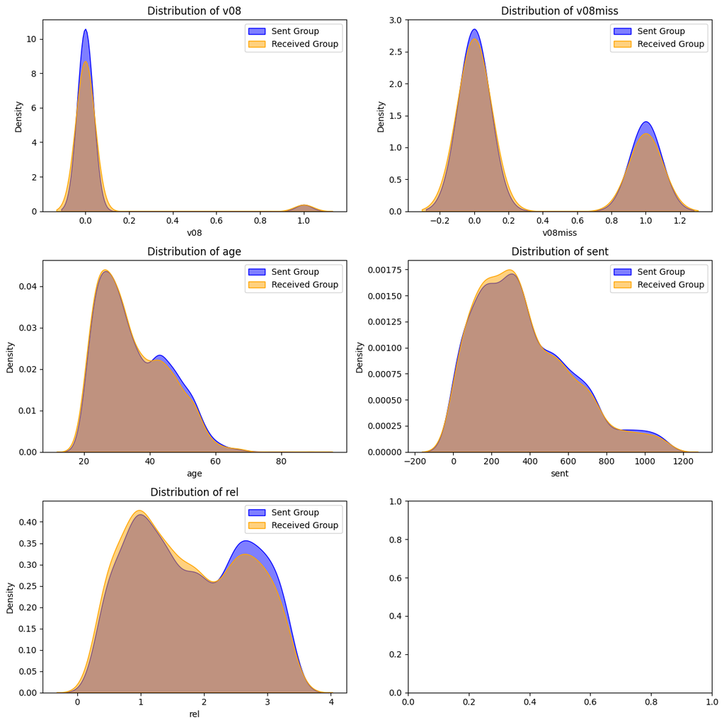

```python
# 우편 발송받은 그룹과 실제 수령한 그룹으로 나누기
sent_group = df[df['mail'] == 1]  # 우편 발송받은 그룹
received_group = df[df['rec'] == 1]  # 실제 수령한 그룹

# EDA: 그룹 간의 통계치 비교
summary = pd.DataFrame({
    'Sent Group': sent_group[['v08', 'age', 'sent', 'rel', 'v08miss']].describe().loc['mean'],
    'Received Group': received_group[['v08', 'age', 'sent', 'rel', 'v08miss']].describe().loc['mean']
})

print("Group Comparison Summary:")
print(summary)

# EDA: 각 변수에 대한 분포 시각화
fig, axes = plt.subplots(3, 2, figsize=(12, 12))
axes = axes.flatten()

# 변수 리스트
variables = ['v08', 'v08miss', 'age', 'sent', 'rel']

for i, var in enumerate(variables):
    sns.kdeplot(sent_group[var], label='Sent Group', ax=axes[i], fill=True, color='blue', alpha=0.5)
    sns.kdeplot(received_group[var], label='Received Group', ax=axes[i], fill=True, color='orange', alpha=0.5)
    axes[i].set_title(f'Distribution of {var}')
    axes[i].legend()

plt.tight_layout()
plt.show()
```

#### 2. 분포 시각화

- 우편 발송을 받은 그룹과, 실제로 우편을 받은 그룹, 두 그룹 간의 분포가 얼추 유사하다.

### (b)

#### Does this hold by design? Why?

NUC 가정(Assume actual receipt of the mailing is unconfounded given the covariates.)은 처치 변수, 즉 메일 발송이 무작위화되어 있고, 공변량들이 충분히 관측되었다면 리서치 디자인상 성립할 수 있다.

#### Justify the estimator you choose

NUC 가정 하에서, 혼란 변수들이 이미 통제 되었다면 Doubly Robust 추정기를 선택할 것이다. 처치 변수가 적용이 된 그룹과 안 된 그룹의 공변량 분포도 비슷하게 맞출 수 있으며(처치 확률 모델), Plug-in 모델의 정보도 활용하기 때문에 통계적 효율성이 높다.

```python
df.info()
```

```
<class 'pandas.core.frame.DataFrame'>
RangeIndex: 6441 entries, 0 to 6440
Data columns (total 11 columns):
 #   Column   Non-Null Count  Dtype
---  ------   --------------  -----
 0   mail     6441 non-null   float64
 1   reg      6441 non-null   float64
 2   v12      6441 non-null   float64
 3   v08      6441 non-null   float64
 4   rec      6441 non-null   float64
 5   age      6441 non-null   float64
 6   crime    6441 non-null   object
 7   sent     6441 non-null   float64
 8   rel      6441 non-null   float64
 9   v08miss  6441 non-null   float64
 10  crime2   6441 non-null   object
dtypes: float64(9), object(2)
memory usage: 553.6+ KB
```

```python
import numpy as np
from sklearn.linear_model import LogisticRegression, LinearRegression
from sklearn.utils import resample
from tqdm import tqdm

# Define covariates, treatment, and outcome
covariates = ['v08', 'v08miss', 'age', 'crime', 'sent', 'rel'] + [col for col in df.columns if 'crime2_' in col]
treatment = 'rec'
outcome = 'reg'

# Encode categorical variables (if not already encoded)
df = pd.get_dummies(df, columns=['crime', 'crime2'], drop_first=True)

# Update covariates after encoding
covariates = ['v08', 'v08miss', 'age', 'sent', 'rel'] + [col for col in df.columns if 'crime_' in col or 'crime2_' in col]

# Propensity score model
propensity_model = LogisticRegression()
propensity_model.fit(df[covariates], df[treatment])
propensity_scores = propensity_model.predict_proba(df[covariates])[:, 1]

# Outcome model
outcome_model = LinearRegression()
outcome_model.fit(df[covariates + [treatment]], df[outcome])

# Predict outcomes under treated and untreated
treated_df = df.copy()
treated_df[treatment] = 1
untreated_df = df.copy()
untreated_df[treatment] = 0

outcome_treated = outcome_model.predict(treated_df[covariates + [treatment]])
outcome_untreated = outcome_model.predict(untreated_df[covariates + [treatment]])

# Compute Doubly Robust Estimator
weights_treated = df[treatment] / propensity_scores
weights_untreated = (1 - df[treatment]) / (1 - propensity_scores)

doubly_robust_estimate = np.mean(weights_treated * (df[outcome] - outcome_untreated) +
                                 weights_untreated * outcome_treated)

# Bootstrap for 95% CI
n_bootstraps = 1000
bootstrap_estimates = []

for _ in tqdm(range(n_bootstraps)):
    sample = resample(df, replace=True, random_state=np.random.randint(1e6))

    # Re-fit models on bootstrap sample
    propensity_model.fit(sample[covariates], sample[treatment])
    propensity_scores_sample = propensity_model.predict_proba(sample[covariates])[:, 1]
    outcome_model.fit(sample[covariates + [treatment]], sample[outcome])

    # Predict outcomes under treated and untreated for bootstrap sample
    outcome_treated_sample = outcome_model.predict(treated_df[covariates + [treatment]])
    outcome_untreated_sample = outcome_model.predict(untreated_df[covariates + [treatment]])

    # Compute weights for treated and untreated groups in bootstrap sample
    weights_treated_sample = sample[treatment] / propensity_scores_sample
    weights_untreated_sample = (1 - sample[treatment]) / (1 - propensity_scores_sample)

    # Compute doubly robust estimate for bootstrap sample
    bootstrap_estimate = np.mean(
        weights_treated_sample * (sample[outcome] - outcome_untreated_sample) +
        weights_untreated_sample * outcome_treated_sample
    )
    bootstrap_estimates.append(bootstrap_estimate)

# Compute 95% confidence interval
lower_bound = np.percentile(bootstrap_estimates, 2.5)
upper_bound = np.percentile(bootstrap_estimates, 97.5)

print("Doubly Robust Estimate:", doubly_robust_estimate)
print("95% Confidence Interval:", (lower_bound, upper_bound))
```

[output not shown]

[output not shown]

[output cut: 6604 more lines]

[output not shown]

```
Doubly Robust Estimate: 0.11583510751451707
95% Confidence Interval: (0.09161209954438694, 0.14293540268657703)
```

#### Estimate the effect of actually receiving the mailing on voter registration, and provide a 95% CI.

- Doubly Robust Estimate: 0.1158
  - 메일을 실제로 받은 경우가 그렇지 않은 경우에 비해 'reg'에 약 11.58%의 증가 효과를 가져온다는 것을 의미한다.
- 95% Confidence Interval: (0.0916, 0.1429)
  - 메일 수신이 유권자 등록률에 미치는 실제 효과는 9.16%에서 14.29% 사이일 가능성이 95%이다.
  - 신뢰구간이 0을 포함하지 않으므로, 이 효과는 통계적으로 유의미하다고 볼 수 있다. 즉, 메일을 받은 것이 유권자 등록에 실제로 긍정적인 영향을 미쳤다고 해석할 수 있다.

### (c)

#### 1. Exclusion Restriction

- 이것이 성립한다는 것은, 우편 수령이 유권자 등록에 영향을 미치는 유일한 방법이라는 뜻이다. 다른 변수, 예를 들어, 사회적 요인이나 경제적 요인이 개입하지 않아야 한다.
- 타당한가? 아니다.
- 실제로 우편을 수령한 후에 사회적 상호작용이나 추가적인 정보, 예를 들어, 친구나 가족의 영향 혹은 미디어 등이 등록에 영향을 줄 수 있다. 고로, 이 가정은 성립하기 어려울 것 같다.

#### 2. Monotonicity

- 우편 수령이라는 조치가 모든 개체에게 일관되게 영향을 미친다는 가정이다. 즉, 조치가 시행된 후 모든 개체의 결과가 동일한 방향으로 변화한다는 것이다. 이 연구에서는 우편을 수령한 사람들에 대해서 반드시 유권자 등록률이 증가한다는 것을 의미한다. 즉, 우편을 수령한 사람들은 그 우편이 없었을 때보다 등록할 가능성이 더 높아야 한다.
- 타당한가? 아니다.
- 모든 개체가 동일한 방향으로 결과가 변화하지 않을 수 있다.

## (d)

#### Who are the compliers in this study?

도구변수(mail)에 따라 실제 처치(rec)를 따르는 사람들이다. 즉, 메일을 발송했을 때 실제로 받은 사람과, 메일을 발송하지 않았을 때 실제로 받지 않은 사람을 말한다.

```python
# Define compliers
compliers = df[
    ((df['mail'] == 1) & (df['rec'] == 1)) |
    ((df['mail'] == 0) & (df['rec'] == 0))
]
compliers
```

|  | mail | reg | v12 | v08 | rec | age | sent | rel | v08miss | crime_ASSAULT, SECOND DEGREE | ... | crime2_BURG | crime2_CARR | crime2_CRIM | crime2_ESCA | crime2_FAIL | crime2_FORG | crime2_LARC | crime2_POSS | crime2_ROBB | crime2_SALE |
| --- | --- | --- | --- | --- | --- | --- | --- | --- | --- | --- | --- | --- | --- | --- | --- | --- | --- | --- | --- | --- | --- |
| 0 | 0.0 | 0.0 | 0.0 | 0.0 | 0.0 | 49.770206 | 357.669403 | 2.650674 | 1.0 | False | ... | False | False | False | False | False | False | False | False | False | True |
| 1 | 1.0 | 0.0 | 0.0 | 0.0 | 1.0 | 33.800426 | 594.564453 | 0.677027 | 0.0 | False | ... | True | False | False | False | False | False | False | False | False | False |
| 2 | 0.0 | 0.0 | 0.0 | 1.0 | 0.0 | 22.849304 | 286.603333 | 0.633061 | 0.0 | True | ... | False | False | False | False | False | False | False | False | False | False |
| 3 | 0.0 | 0.0 | 0.0 | 0.0 | 0.0 | 41.508663 | 580.255066 | 1.544256 | 0.0 | False | ... | False | False | True | False | False | False | False | False | False | False |
| 4 | 1.0 | 0.0 | 0.0 | 0.0 | 1.0 | 27.735893 | 813.326172 | 0.649590 | 0.0 | False | ... | True | False | False | False | False | False | False | False | False | False |
| ... | ... | ... | ... | ... | ... | ... | ... | ... | ... | ... | ... | ... | ... | ... | ... | ... | ... | ... | ... | ... | ... |
| 6435 | 1.0 | 1.0 | 1.0 | 0.0 | 1.0 | 49.932598 | 97.503944 | 1.943091 | 0.0 | False | ... | False | False | False | False | False | False | True | False | False | False |
| 6436 | 1.0 | 0.0 | 0.0 | 1.0 | 1.0 | 31.865318 | 811.128967 | 0.484666 | 0.0 | False | ... | False | False | False | False | False | False | False | False | False | True |
| 6438 | 0.0 | 0.0 | 0.0 | 0.0 | 0.0 | 28.739668 | 938.236572 | 0.925671 | 1.0 | False | ... | True | False | False | False | False | False | False | False | False | False |
| 6439 | 1.0 | 0.0 | 0.0 | 0.0 | 1.0 | 47.281754 | 244.693420 | 1.922816 | 0.0 | False | ... | False | False | False | False | False | False | False | False | False | True |
| 6440 | 0.0 | 0.0 | 0.0 | 0.0 | 0.0 | 44.057796 | 432.752380 | 0.436283 | 0.0 | False | ... | False | False | False | False | True | False | False | False | False | False |

5183 rows × 55 columns

```python
from sklearn.linear_model import LinearRegression
import numpy as np
from tqdm import tqdm
from sklearn.utils import resample

# Define covariates, instrument, treatment, and outcome
covariates = ['v08', 'v08miss', 'age', 'sent', 'rel'] + [col for col in df.columns if 'crime2_' in col or 'crime_' in col]
instrument = 'mail'
treatment = 'rec'
outcome = 'reg'

# Step 1: Estimate E(Y | X, Z) and E(A | X, Z) for compliers
def estimate_conditional_expectation(df, covariates, variable, instrument_value):
    """Fit linear regression and predict conditional expectation."""
    subset = df[df[instrument] == instrument_value]
    model = LinearRegression()
    model.fit(subset[covariates], subset[variable])
    return model.predict(df[covariates])

# Calculate E(Y | X, Z) and E(A | X, Z) for compliers
e_y_given_x_z1 = estimate_conditional_expectation(compliers, covariates, outcome, instrument_value=1)
e_y_given_x_z0 = estimate_conditional_expectation(compliers, covariates, outcome, instrument_value=0)
e_a_given_x_z1 = estimate_conditional_expectation(compliers, covariates, treatment, instrument_value=1)
e_a_given_x_z0 = estimate_conditional_expectation(compliers, covariates, treatment, instrument_value=0)

# Step 2: Compute LATE for compliers
numerator = np.mean(e_y_given_x_z1 - e_y_given_x_z0)
denominator = np.mean(e_a_given_x_z1 - e_a_given_x_z0)
late_estimate = numerator / denominator

# Step 3: Bootstrap for 95% confidence interval
n_bootstraps = 1000
bootstrap_estimates = []

for _ in tqdm(range(n_bootstraps)):
    # Resample compliers
    bootstrap_sample = resample(compliers, replace=True)

    # Re-estimate conditional expectations
    e_y_given_x_z1_bs = estimate_conditional_expectation(bootstrap_sample, covariates, outcome, instrument_value=1)
    e_y_given_x_z0_bs = estimate_conditional_expectation(bootstrap_sample, covariates, outcome, instrument_value=0)
    e_a_given_x_z1_bs = estimate_conditional_expectation(bootstrap_sample, covariates, treatment, instrument_value=1)
    e_a_given_x_z0_bs = estimate_conditional_expectation(bootstrap_sample, covariates, treatment, instrument_value=0)

    # Calculate bootstrap LATE
    numerator_bs = np.mean(e_y_given_x_z1_bs - e_y_given_x_z0_bs)
    denominator_bs = np.mean(e_a_given_x_z1_bs - e_a_given_x_z0_bs)
    bootstrap_estimates.append(numerator_bs / denominator_bs)

# Compute confidence intervals
lower_bound = np.percentile(bootstrap_estimates, 2.5)
upper_bound = np.percentile(bootstrap_estimates, 97.5)

# Print results
print("Local Average Treatment Effect (LATE) among compliers:", late_estimate)
print("95% Confidence Interval:", (lower_bound, upper_bound))
```

```
Local Average Treatment Effect (LATE) among compliers: 0.029272746212444696
95% Confidence Interval: (0.01393965324802418, 0.043087660829989785)
```

#### Justify the estimator you choose

- Exclusion Restriction, Monotonicity가 있을 때, LATE는 compliers에 대한 치료 효과를 잘 식별할 수 있다. Exclusion Restriction을 통해 도구변수(mail)가 결과 변수(reg)에 영향을 미치는 유일한 경로는 처치(rec)를 통해서임이 보장되며, Monotonicity는 도구변수가 처치에 일관된 방향으로만 영향을 미치도록 해주기 때문이다. 이를 기반으로 LATE는 도구변수에 따라 처치를 받은 Compliers 집단에서 결과 변수에 대한 평균적 인과 효과를 신뢰성 있게 추정한다.

#### Estimate the local average effect of receiving the mailing on registration, among compliers, and provide a 95% CI.

- LATE : 0.0293(약 2.93%)
  - 메일을 발송했을 때 유권자 등록률이 약 2.93% 증가한 것으로 볼 수 있다.
- 95% CI : (0.0139, 0.0431)
  - 신뢰구간이 0을 포함하지 않으므로, 이 효과는 통계적으로 유의미하다고 볼 수 있다.

## 3.

### (a)

1. 혼란 변수
- 난로 사용 여부와 건강 결과 간의 관계에 영향을 미치는 외부 요인, 예를 들어, 소득이나 다른 환경적 요인 등이 있을 수 있다. 이러한 요인들이 통제되지 않으면, 건강 결과에 대한 왜곡된 해석이 발생할 수 있다.
1. 선택 편향(Selection Bias)
- 부유한 마을의 사람들이 전통 난로 대신 새로운 난로를 사용했다는 점에서, 이러한 편향으로 인해 그들의 건강 결과가 난로 사용 여부에 영향을 받을 수 있다.
1. 랜덤마이제이션 부족
- 실험적 설계가 아닌 경우, 참가자들이 난로를 선택하는 과정이 무작위가 아니므로 두 그룹 간의 비교가 불공정할 수 있다.

### (b)

- 장점
1. 실험에서는 랜덤화를 통해 외부 변수의 영향을 최소화할 수 있을 것이다.
- 단점
1. 소규모 실험에서는 통계적 검정력이 떨어질 수 있으며, 실제로 효과가 존재하더라도 유의미한 결과를 얻지 못할 위험이 있다.
2. 특정 마을에서만 선별되었다는 이유로, 이미 편향이 존재할 수 있다.

### (c)

#### 1. What do you think of this analysis?

- X의 공변량은 잘 처리가 된 듯하나, 선택 편향이 여전히 존재한다고 생각한다.
- 그리고 Defier들이 많이 존재한다. 20%의 사람들이 새로운 난로를 사용하지 않았고, 5%의 대조군에서는 난로를 구입했으므로, 치료군과 대조군 간의 비교가 불공정할 수 있으며, 효과 추정이 왜곡될 수 있다.

#### 2. What assumptions does it require?

- 독립성 가정: 각 관측치는 서로 독립적이어야 한다. 이는 로지스틱 회귀 분석의 기본적인 가정이다.
- 정규성 가정: 로지스틱 회귀는 로그 오즈에 대한 선형성을 가정한다. 즉, 독립 변수가 종속 변수의 로그 오즈와 선형적 관계를 가져야 한다.
- NUC: 모든 잠재적인 혼란 변수가 모델에 포함되어 있다고 가정해야 한다.
- 처치 그룹과 대조 그룹에 선택적 편향이 존재하지만, 두 그룹의 공변량에 대한 분포가 비슷하다는 가정이 있어야 할 것이다.

#### 3. Would you recommend a different approach? If so, which one(s) and why?

- IV analysis
- 여기서는 Non-compliance가 발생했으므로, 무작위 할당만으로는 실제로 난로를 사용한 사람과 그렇지 않은 사람들 간의 순수한 인과 관계를 정확히 추정하기 어렵다.
- IV 분석은 Defier가 있는 상황에서도 내재된 편향을 줄일 수 있다.

### (d)

- 실험 그룹 중 80%가 실제로 새 난로를 사용했고, 나머지 20%는 사용하지 않았으며, 통제 그룹에서 5%가 새 난로를 사용했다.
- 따라서, **strength = 80% - 5% = 75%** 이다.
- 75% strength는 도구변수가 실제로 새 난로 사용 여부에 상당한 영향을 미친다는 것을 나타낸다. 도구변수가 처치와 강하게 연결되어 있으며, 분석에서 도구 변수가 유용한 예측 변수로 기능할 가능성을 높인다.
- 이 강도는 다음과 같은 조건 하에서 의미를 가진다.
  - Consistency
  - Positivity
  - Unconfoundedness
  - Monotonicity
  - Relevance

### (e)

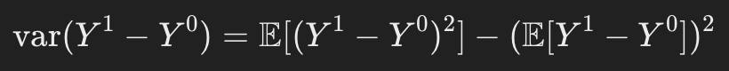

만약 회귀 모델을 이용한다면,

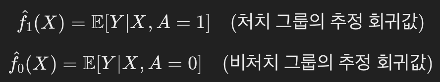

처치 효과의 추정값은 다음과 같으며,

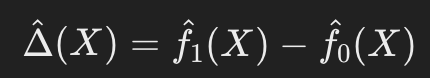

처치 효과 분산의 추정값은 다음과 같다.

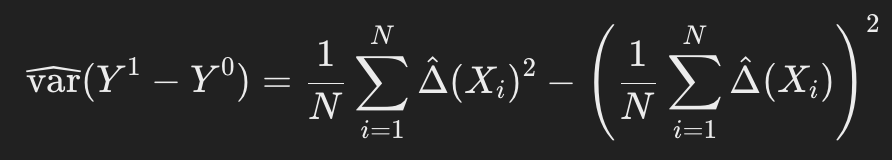

A⊥Y^a ∣ X 조건(NUC)이 충족된다면, 관찰 데이터의 분포로부터 처치 효과의 분산을 식별할 수 있다.